# Assignment_3

# API’s

## Download the Data

```r
library(data.table)
library(stringr)
library(rvest)
library(xml2)
library(httr)
library(tidyverse)
library(tidytext)
library(tibble)
library(forcats)
```

## Using the NCBI API, look for papers that show up under the term “sars-cov-2 trial vaccine.” Look for the data in the pubmed database, and then retrieve the details of the paper as shown in lab 7. How many papers were you able to find?

```r
# Downloading the website
website <- xml2::read_html("https://pubmed.ncbi.nlm.nih.gov/?term=sars-cov-2+trial+vaccine")

# Finding the counts
counts <- xml2::xml_find_first(website, "/html/body/main/div[9]/div[2]/div[2]/div[1]/div[1]/span")

# Turning it into text
counts <- as.character(counts)

# Extracting the data using regex
stringr::str_extract(counts, "[0-9,]+")
```

```
## [1] "2,335"
```

```r
stringr::str_replace(counts, "[^[:digit:]]+([[:digit:]]+),([[:digit:]]+)[^[:digit:]]+","\\1\\2")
```

```
## [1] "2335"
```

I was able to find 2,335 papers under the term “sars-cov-2 trial vaccine”.

## Using the list of pubmed ids you retrieved, download each papers’ details using the query parameter rettype = abstract. If you get more than 250 ids, just keep the first 250.

```r
query_ids <- GET(
  url   = "https://eutils.ncbi.nlm.nih.gov/entrez/eutils/esearch.fcgi",
  query = list(db = "pubmed",term= "sars-cov-2 trial vaccine",retmax=1000)
)
ids <- httr::content(query_ids)
```

```r
# Turn the result into a character vector
ids <- as.character(ids)

# Find all the ids
ids <- stringr::str_extract_all(ids, "<Id>[[:digit:]]+</Id>")[[1]]

# Remove all the leading and trailing <Id> </Id>. Make use of "|"
ids <- stringr::str_remove_all(ids, "<Id>|</Id>")
# Keep first 250 ids
ids <- ids[1:250]
#Get the Publications
publications <- GET(
  url   = "https://eutils.ncbi.nlm.nih.gov/entrez/eutils/efetch.fcgi",
  query = list(
    db = "pubmed",id=I(paste(ids,collapse=",")),retmax=1000,rettype="abstract"
    )
)

# Turning the output into character vector
publications <- httr::content(publications)
publications_txt <- as.character(publications)
```

```r
#University & Institute Case
pub_char_list <- xml2::xml_children(publications)
pub_char_list <- sapply(pub_char_list, as.character)

#extracting abstracts
abstracts <- str_extract(pub_char_list, "<Abstract>[[:print:][:space:]]+</Abstract>")
abstracts <- str_remove_all(abstracts, "</?[[:alnum:]- =\"]+>")
abstracts <- str_replace_all(abstracts, "[[:space:]]+", " ")

#extracting titles
titles <- str_extract(pub_char_list, "<ArticleTitle>[[:print:][:space:]]+</ArticleTitle>")
titles <- str_remove_all(titles, "</?[[:alnum:]- =\"]+>")

#extract jounal names
journalname <- str_extract(pub_char_list, "<Title>[[:print:][:space:]]+</Title>")
journalname <- str_remove_all(journalname, "</?[[:alnum:]- =\"]+>")
journalname <- str_replace_all(journalname, "[[:space:]]+", " ")

#extract publication date
publication_date <- str_extract(pub_char_list, "<PubDate>[[:print:][:space:]]+</PubDate>")
publication_date <- str_remove_all(publication_date, "</?[[:alnum:]- =\"]+>")
publication_date <- str_replace_all(publication_date, "[[:space:]]+", " ")

database <- data.frame(
  PubMedId = ids,
  Title = titles,
  Journal_Name = journalname,
  Publication_Date = publication_date,
  Abstract = abstracts
)
knitr::kable(database[1:10,], caption="SARS-COV2 Trial Vaccine Papers")
```

SARS-COV2 Trial Vaccine Papers

| PubMedId | Title | Journal_Name | Publication_Date | Abstract |
| --- | --- | --- | --- | --- |
| 34729549 | Adverse events of active and placebo groups in SARS-CoV-2 vaccine randomized trials: A systematic review. | The Lancet regional health. Europe | 2021 Oct 28 | For safety assessment in clinical trials, adverse events (AEs) are reported for the drug under evaluation and compared with AEs in the placebo group. Little is known about the nature of the AEs associ… |
| 34726743 | Analysis of the Effectiveness of the Ad26.COV2.S Adenoviral Vector Vaccine for Preventing COVID-19. | JAMA network open | 2021 11 01 | Continuous assessment of the effectiveness and safety of the US Food and Drug Administration-authorized SARS-CoV-2 vaccines is critical to amplify transparency, build public trust, and ultimately impr… |
| 34715931 | Lessons from Israel’s COVID-19 Green Pass program. | Israel journal of health policy research | 2021 10 29 | As of the beginning of March 2021, Israeli law requires the presentation of a Green Pass as a precondition for entering certain businesses and public spheres. Entitlement for a Green Pass is granted t… |
| 34713912 | Vaccine development and technology for SARS-CoV-2: current insights. | Journal of medical virology | 2021 Oct 29 | SARS-CoV-2 is associated to a severe respiratory disease in China, that rapidly spread across continents. Since the beginning of the pandemic, available data suggested the asymptomatic transmission an… |
| 34711598 | BCG vaccination to reduce the impact of COVID-19 in healthcare workers: Protocol for a randomised controlled trial (BRACE trial). | BMJ open | 2021 10 28 | BCG vaccination modulates immune responses to unrelated pathogens. This off-target effect could reduce the impact of emerging pathogens. As a readily available, inexpensive intervention that has a wel… |
| 34704204 | COVID-19 Testing and Vaccine Acceptability Among Homeless-Experienced Adults: Qualitative Data from Two Samples. | Journal of general internal medicine | 2021 Oct 26 | Homeless-experienced populations are at increased risk of exposure to SARS-CoV-2 due to their living environments and face an increased risk of severe COVID-19 disease due to underlying health conditi… |
| 34703690 | A Rare Variant of Guillain-Barre Syndrome Following Ad26.COV2.S Vaccination. | Cureus | 2021 Sep | Efforts to combat the global pandemic caused by severe acute respiratory syndrome coronavirus 2 (SARS-CoV-2) range from adequate diagnostic testing and contract tracing to vaccination for the preventi… |
| 34702753 | Humoral immunogenicity of the seasonal influenza vaccine before and after CAR-T-cell therapy: a prospective observational study. | Journal for immunotherapy of cancer | 2021 10 | Recipients of chimeric antigen receptor-modified T (CAR-T) cell therapies for B cell malignancies have profound and prolonged immunodeficiencies and are at risk for serious infections, including respi… |
| 34698827 | Measuring vaccine efficacy against infection and disease in clinical trials: sources and magnitude of bias in COVID-19 vaccine efficacy estimates. | Clinical infectious diseases : an official publication of the Infectious Diseases Society of America | 2021 Oct 26 | Phase III trials have estimated COVID-19 vaccine efficacy (VE) against symptomatic and asymptomatic infection. We explore the direction and magnitude of potential biases in these estimates and their i… |
| 34697214 | Author Response: Guillain-Barré Syndrome in the Placebo and Active Arms of a COVID-19 Vaccine Clinical Trial. | Neurology | 2021 10 26 | NA |

# Text Mining

## Download Data

```r
fn <- "pubmed.csv"
if (!file.exists(fn))
  download.file("https://raw.githubusercontent.com/USCbiostats/data-science-data/master/03_pubmed/pubmed.csv", destfile=fn)

pubmed <- read.csv(fn)
pubmed <- as_tibble(pubmed)
```

## Tokenize the abstracts and count the number of each token. Do you see anything interesting? Does removing stop words change what tokens appear as the most frequent? What are the 5 most common tokens for each search term after removing stopwords?

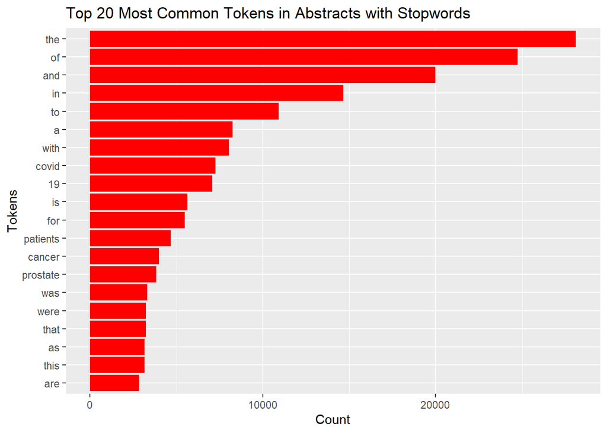

```r
pubmed %>%
  unnest_tokens(output = word, input = abstract) %>%
  count(word, sort = TRUE) %>%
  top_n(20) %>%
  ggplot (aes(x=n, y=fct_reorder(word,n)))+
  geom_col(fill="red") +
  labs(title = "Top 20 Most Common Tokens in Abstracts with Stopwords", y= "Tokens", x="Count")
```

## Take out Stopwords

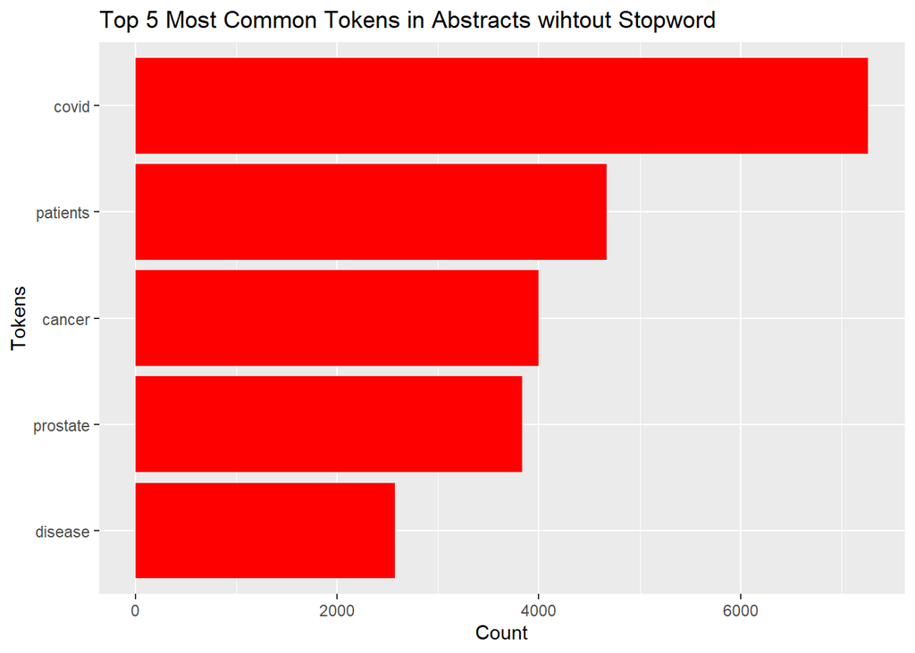

```r
pubmed %>%
  unnest_tokens(output = word, input = abstract) %>%
  count(word, sort = TRUE) %>%
  anti_join(stop_words, by ="word") %>%
  #using regex to remove numbers
  filter(!grepl("^[0-9]+$",x=word)) %>%
  top_n(5) %>%
  ggplot (aes(x=n, y=fct_reorder(word,n)))+
  geom_col(fill="red") +
  labs(title = "Top 5 Most Common Tokens in Abstracts wihtout Stopword", y= "Tokens", x="Count")
```

From the graph above, we see that the 5 most common tokens are covid, patients, cancer, prostate, and disease, which is different from the previous graph due to the removal of stop words.

```r
pubmed %>%
  unnest_tokens(output = word, input = abstract) %>%
  anti_join(stop_words, by ="word") %>%
  group_by(term) %>%
  count(word) %>%
  top_n(5,n) %>%
  knitr::kable(caption = "The Top 5 Most Common Tokens for each search Term after Stopwords Removal")
```

The Top 5 Most Common Tokens for each search Term after Stopwords Removal

| term | word | n |
| --- | --- | --- |
| covid | 19 | 7035 |
| covid | covid | 7267 |
| covid | disease | 943 |
| covid | pandemic | 800 |
| covid | patients | 2292 |
| cystic fibrosis | cf | 625 |
| cystic fibrosis | cystic | 862 |
| cystic fibrosis | disease | 400 |
| cystic fibrosis | fibrosis | 867 |
| cystic fibrosis | patients | 586 |
| meningitis | clinical | 187 |
| meningitis | csf | 206 |
| meningitis | meningeal | 219 |
| meningitis | meningitis | 429 |
| meningitis | patients | 446 |
| preeclampsia | eclampsia | 2005 |
| preeclampsia | pre | 2031 |
| preeclampsia | preeclampsia | 1863 |
| preeclampsia | pregnancy | 969 |
| preeclampsia | women | 1196 |
| prostate cancer | cancer | 3840 |
| prostate cancer | disease | 652 |
| prostate cancer | patients | 934 |
| prostate cancer | prostate | 3832 |
| prostate cancer | treatment | 926 |

From the Table above, we see that the top 5 tokens from each search term by count. For each search term, the top 5 highest tokens by count are as follows:

**covid**: 19,covid,disease,pandemic,patients  
**cystic fibrosis**: cf, cystic, disease, fibrosis, patients  
**meningitis**: clinical, csf, meningeal, meningitis, patients  
**preeclampsia**: eclampsia, pre,preeclampsia,pegnancy,women  
**prostate cancer**: cancer, disease, patients, prostate, treatment

## Tokenize the abstracts into bigrams. Find the 10 most common bigram and visualize them with ggplot2.

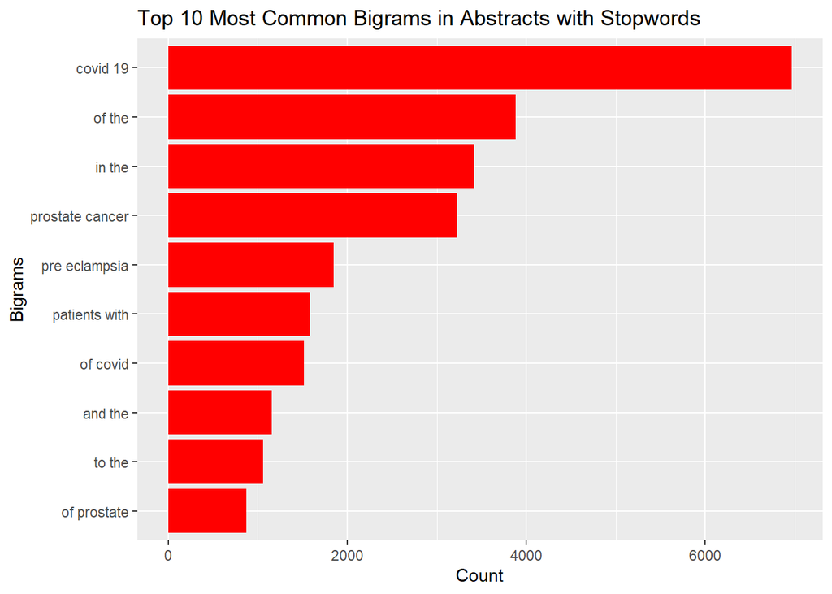

```r
pubmed %>%
  unnest_ngrams(output = bigram, input = abstract, n = 2) %>%
  count(bigram, sort = TRUE) %>%
  top_n(10) %>%
  ggplot (aes(x=n, y=fct_reorder(bigram,n)))+
  geom_col(fill="red")+
  labs(title = "Top 10 Most Common Bigrams in Abstracts with Stopwords", y= "Bigrams", x="Count")
```

The 10 most common bigrams, as depicted in the graph above are, covid 19, of the, in the, prostate cancer, pre eclampsie, patients with, of covid, and the, to the, and of prostate.

## Calculate the TF-IDF value for each word-search term combination. (here you want the search term to be the “document”) What are the 5 tokens from each search term with the highest TF-IDF value? How are the results different from the answers you got in question 1?

```r
pubmed %>%
  unnest_tokens(output = word, input = abstract) %>%
  count(word,term) %>%
  bind_tf_idf(word,term,n) %>%
  group_by(term) %>%
  top_n(5,tf_idf) %>%
  arrange(desc(tf_idf), .by_group = TRUE) %>%
  knitr::kable(caption="Top 5 Tokens with the Highest TF-IDF Value")
```

Top 5 Tokens with the Highest TF-IDF Value

| word | term | n | tf | idf | tf_idf |
| --- | --- | --- | --- | --- | --- |
| covid | covid | 7267 | 0.0370348 | 1.6094379 | 0.0596052 |
| pandemic | covid | 800 | 0.0040770 | 1.6094379 | 0.0065617 |
| coronavirus | covid | 647 | 0.0032973 | 1.6094379 | 0.0053068 |
| sars | covid | 371 | 0.0018907 | 1.6094379 | 0.0030430 |
| cov | covid | 333 | 0.0016971 | 1.6094379 | 0.0027313 |
| cf | cystic fibrosis | 625 | 0.0127164 | 0.9162907 | 0.0116520 |
| fibrosis | cystic fibrosis | 867 | 0.0176402 | 0.5108256 | 0.0090111 |
| cystic | cystic fibrosis | 862 | 0.0175385 | 0.5108256 | 0.0089591 |
| cftr | cystic fibrosis | 86 | 0.0017498 | 1.6094379 | 0.0028162 |
| sweat | cystic fibrosis | 83 | 0.0016887 | 1.6094379 | 0.0027179 |
| meningitis | meningitis | 429 | 0.0091891 | 1.6094379 | 0.0147892 |
| meningeal | meningitis | 219 | 0.0046909 | 1.6094379 | 0.0075497 |
| pachymeningitis | meningitis | 149 | 0.0031915 | 1.6094379 | 0.0051366 |
| csf | meningitis | 206 | 0.0044125 | 0.9162907 | 0.0040431 |
| meninges | meningitis | 106 | 0.0022705 | 1.6094379 | 0.0036542 |
| eclampsia | preeclampsia | 2005 | 0.0142711 | 1.6094379 | 0.0229684 |
| preeclampsia | preeclampsia | 1863 | 0.0132604 | 1.6094379 | 0.0213417 |
| pregnancy | preeclampsia | 969 | 0.0068971 | 0.5108256 | 0.0035232 |
| maternal | preeclampsia | 797 | 0.0056728 | 0.5108256 | 0.0028978 |
| gestational | preeclampsia | 191 | 0.0013595 | 1.6094379 | 0.0021880 |
| prostate | prostate cancer | 3832 | 0.0311808 | 1.6094379 | 0.0501836 |
| androgen | prostate cancer | 305 | 0.0024818 | 1.6094379 | 0.0039943 |
| psa | prostate cancer | 282 | 0.0022946 | 1.6094379 | 0.0036931 |
| prostatectomy | prostate cancer | 215 | 0.0017494 | 1.6094379 | 0.0028156 |
| castration | prostate cancer | 148 | 0.0012043 | 1.6094379 | 0.0019382 |

From the Table above, we see that the top 5 tokens from each search term with the highest TF-IDF value. For each search term, the top 5 highest tokens by TF-IDF values are as follows:

**covid**: covid, pandemic, coronavirus, sars, cov  
**cystic fibrosis**: cf, fibrosis, cystic, cftr, sweat  
**meningitis**: meningitis, meningeal, pachymeningitis, csf, meninges  
**preeclampsia**: eclampsia, preeclampsia, pregnancy, maternal, gestational  
**prostate cancer**: prostate, androgen, psa, prostatectomy, castration